# Assignment 6: Logistic regression

Marton Kovacs / Zoltan Kekecs

# Background story

In this lab assignment you are going to work with data related to the survival of passengers of the RMS Titanic. “The sinking of the Titanic is one of the most infamous shipwrecks in history. On April 15, 1912, during her maiden voyage, the widely considered “unsinkable” RMS Titanic sank after colliding with an iceberg. Unfortunately, there weren’t enough lifeboats for everyone onboard, resulting in the death of 1502 out of 2224 passengers and crew. While there was some element of luck involved in surviving, it seems some groups of people were more likely to survive than others.” (Quote from the Kaggle Titanic Challenge).

For the sake of this assignment, let’s imagine that you are called as an expert to a court case: Kate, one of the survivors of the Titanic accident is suing her **father, Leonardo, for not accompanying Kate and her mother Sue on the trip** and this way decreasing their chances of survival. The family planned to move to the US back in 1912. **They bought 3rd class tickets for the three of them for 8 British Pounds each. (They did not get cabins with their 3rd class tickets.)** The plan was that they embark in Southampton and all of them got on board, but Leonardo got separated from them in the rush of passengers during boarding. Later it turned out that Leonardo deliberately got separated from them and got off the boat before it’s departure, to run away and live with his mistress. **Kate was only 4 at the time, and Sue was 20.** During the accident **Kate got on one of the last lifeboats and was later rescued, but there was no room for Sue on the lifeboat, and she did not survive the disaster.**

Now 20 years later Kate is suing her father for leaving them on the boat, because she thinks that this eventually led to Sue’s death, as the absence of Leonardo decreased their chances of survival.

You are called in as an expert to this court case. Your task is to present a report about whether the presence of Leonardo statistically could have led to an improved chance of survival.

# Dataset

Use the data file called ‘assignment_4_dataset’, from the ‘data/’ folder.

This is the training dataset of the Titanic dataset from the Kaggle Titanic Challenge (https://www.kaggle.com/c/titanic/overview), a prediction challenge for people who are just starting to learn about machine learning and other statistical prediction techniques. The following description is available for the dataset:

## Metadata

```r
library(dplyr)
```

```r
library(haven)
```

[output not shown]

[output cut: 861 more lines]

```r
glimpse(titanic_new01)
```

```
## Rows: 891
## Columns: 12
## $ PassengerId <dbl> 1, 2, 3, 4, 5, 6, 7, 8, 9, 10, 11, 12, 13, 14, 15, 16, 17,…
## $ Survived    <dbl> 0, 1, 1, 1, 0, 0, 0, 0, 1, 1, 1, 1, 0, 0, 0, 1, 0, 1, 0, 1…
## $ Pclass      <dbl> 3, 1, 3, 1, 3, 3, 1, 3, 3, 2, 3, 1, 3, 3, 3, 2, 3, 2, 3, 3…
## $ Name        <chr> "Braund, Mr. Owen Harris", "Cumings, Mrs. John Bradley (Fl…
## $ Sex         <chr> "male", "female", "female", "female", "male", "male", "mal…
## $ Age         <dbl> 22, 38, 26, 35, 35, NA, 54, 2, 27, 14, 4, 58, 20, 39, 14, …
## $ SibSp       <dbl> 1, 1, 0, 1, 0, 0, 0, 3, 0, 1, 1, 0, 0, 1, 0, 0, 4, 0, 1, 0…
## $ Parch       <dbl> 0, 0, 0, 0, 0, 0, 0, 1, 2, 0, 1, 0, 0, 5, 0, 0, 1, 0, 0, 0…
## $ Ticket      <chr> "A/5 21171", "PC 17599", "STON/O2. 3101282", "113803", "37…
## $ Fare        <dbl> 7.2500, 71.2833, 7.9250, 53.1000, 8.0500, 8.4583, 51.8625,…
## $ Cabin       <chr> "", "C85", "", "C123", "", "", "E46", "", "", "", "G6", "C…
## $ Embarked    <chr> "S", "C", "S", "S", "S", "Q", "S", "S", "S", "C", "S", "S"…
```

# Task

As usual, start with exploring your dataset. Do descriptive and exploratory analysis including visualization to understand the data and to see what type of data you are dealing with.

You should build a statistical model with which you can accurately estimate Kate’s and Sue’s chances of survival. First you should fit a statistical model (for example a logistic regression model) on the dataset, calculate the regression equation, and use that equation to compute the survival probability for Kate and Sue separately with and without having Leonardo on board the ship with them.

You can use whichever predictor you would like, but you need to build a model that is at least as accurate so that it can correctly predict the outcome value within the sample with at least 72% accuracy for BOTH those who actually survived and who actually died in the disaster. You need to check this in the Classification table. So it is not enough to have 72% overall correct percentage! In order to be able to reach this prediction accuracy you might have to use some special predictors or to do some feature engineering. A comprehensive exploratory analysis including the visualisation of the relationship of different predictors might help in this. Keep in mind that this is one of the most popular prediction challenges on Kaggle, so there is plenty of discussion and guides on the web about different models and features. If you get stuck, you can look these up to improve your prediction performance.

You do not need to check model assumptions in this assignment (but you can do so if you want to and this might help you improve your prediction performance).

# What to report

When you have arrived at a satisfactory model describe the final model to the reader so that it is clear how is the model built up, and that based on the description the reader could reproduce your model.

Report about the goodness of fit of the model, whether it is significantly better than the null model (based on the AIC and chi^2 test statistics), and how effective is your model at predicting the outcome (based on McFadden R^2, and the correct prediction percentages in the classification table of the final model). Be sure to report the total correct prediction percentage of the final model and also the correct prediction percentages separately for those who actually died, and those who actually survived.

Also, report the statistics describing the coefficients of the predictors in a table format (for each predictor, this table should include the following: logit regression coefficients, Odds ratios, and 95% confidence intervals for the Odds ratios, Chi^2 test statistics and p values, and AIC values for the reduced models).

Report which were the most influential predictors in the model, and which were the predictors which did not seem to have unique added value to the model.

Write up the regression equation of the model in the form of 𝑌 = 𝑏0 + 𝑏1 ∗ X1 + 𝑏2 ∗ X2 +…+ bn * Xn, in which you use the actual regression coefficients of your models. (b0 stands for the intercept and b1, b2 … bn stand for the model coefficients for each of the predictors, and X1, X2, … Xn denote the predictors).

Finally, report the predicted probability of survival for Kate and Sue separately with and without having Leonardo on board the ship with them. (So you will have to estimate 4 probabilities in total, two for Kate and two for Sue). It is important that this is in the probability scale (since the jury does not know what logit means and how to interpret it).

# What to discuss

In your discussion of the findings, briefly interpret the results of the above analyses in light of the court case. Based on your results do you find it likely that the presence of Leonardo (spouse to Sue and parent to Kate) would have improved the survival chances of Sue and Kate? What is the best predictor of survival in the model and how does the presence of a spouse and presence of a parent compare to its influence?

# Solution

## Read the data

Read the dataset used in this assignment. Pay attention to the extension of the datafile.

## EDA

```r
glimpse(titanic_new01)
```

```
## Rows: 891
## Columns: 12
## $ PassengerId <dbl> 1, 2, 3, 4, 5, 6, 7, 8, 9, 10, 11, 12, 13, 14, 15, 16, 17,…
## $ Survived    <dbl> 0, 1, 1, 1, 0, 0, 0, 0, 1, 1, 1, 1, 0, 0, 0, 1, 0, 1, 0, 1…
## $ Pclass      <dbl> 3, 1, 3, 1, 3, 3, 1, 3, 3, 2, 3, 1, 3, 3, 3, 2, 3, 2, 3, 3…
## $ Name        <chr> "Braund, Mr. Owen Harris", "Cumings, Mrs. John Bradley (Fl…
## $ Sex         <chr> "male", "female", "female", "female", "male", "male", "mal…
## $ Age         <dbl> 22, 38, 26, 35, 35, NA, 54, 2, 27, 14, 4, 58, 20, 39, 14, …
## $ SibSp       <dbl> 1, 1, 0, 1, 0, 0, 0, 3, 0, 1, 1, 0, 0, 1, 0, 0, 4, 0, 1, 0…
## $ Parch       <dbl> 0, 0, 0, 0, 0, 0, 0, 1, 2, 0, 1, 0, 0, 5, 0, 0, 1, 0, 0, 0…
## $ Ticket      <chr> "A/5 21171", "PC 17599", "STON/O2. 3101282", "113803", "37…
## $ Fare        <dbl> 7.2500, 71.2833, 7.9250, 53.1000, 8.0500, 8.4583, 51.8625,…
## $ Cabin       <chr> "", "C85", "", "C123", "", "", "E46", "", "", "", "G6", "C…
## $ Embarked    <chr> "S", "C", "S", "S", "S", "Q", "S", "S", "S", "C", "S", "S"…
```

```r
typeof(titanic_new01)
```

```
## [1] "list"
```

```r
nrow(titanic_new01)
```

```
## [1] 891
```

```r
cols <- c("Survived", "Parch","Pclass", "Sex", "Embarked" )
titanic_new01[cols] <- lapply (titanic_new01 [cols], factor)
sapply(titanic_new01, class)
```

```
## PassengerId    Survived      Pclass        Name         Sex         Age
##   "numeric"    "factor"    "factor" "character"    "factor"   "numeric"
##       SibSp       Parch      Ticket        Fare       Cabin    Embarked
##   "numeric"    "factor" "character"   "numeric" "character"    "factor"
```

## Clean the data

```r
class(titanic_new01)
```

```
## [1] "tbl_df"     "tbl"        "data.frame"
```

```r
unique(titanic_new01)
```

```
## # A tibble: 891 × 12
##    PassengerId Survived Pclass Name   Sex     Age SibSp Parch Ticket  Fare Cabin
##          <dbl> <fct>    <fct>  <chr>  <fct> <dbl> <dbl> <fct> <chr>  <dbl> <chr>
##  1           1 0        3      Braun… male     22     1 0     A/5 2…  7.25 ""
##  2           2 1        1      Cumin… fema…    38     1 0     PC 17… 71.3  "C85"
##  3           3 1        3      Heikk… fema…    26     0 0     STON/…  7.92 ""
##  4           4 1        1      Futre… fema…    35     1 0     113803 53.1  "C12…
##  5           5 0        3      Allen… male     35     0 0     373450  8.05 ""
##  6           6 0        3      Moran… male     NA     0 0     330877  8.46 ""
##  7           7 0        1      McCar… male     54     0 0     17463  51.9  "E46"
##  8           8 0        3      Palss… male      2     3 1     349909 21.1  ""
##  9           9 1        3      Johns… fema…    27     0 2     347742 11.1  ""
## 10          10 1        2      Nasse… fema…    14     1 0     237736 30.1  ""
## # … with 881 more rows, and 1 more variable: Embarked <fct>
```

```r
sum(is.na(titanic_new01$PassengerId))
```

```
## [1] 0
```

```r
sum(is.na(titanic_new01$Survived))
```

```
## [1] 0
```

```r
sum(is.na(titanic_new01$Pclass))
```

```
## [1] 0
```

```r
sum(is.na(titanic_new01$Name))
```

```
## [1] 0
```

```r
sum(is.na(titanic_new01$Sex))
```

```
## [1] 0
```

```r
sum(is.na(titanic_new01$Age))
```

```
## [1] 177
```

```r
sum(is.na(titanic_new01$SibSp))
```

```
## [1] 0
```

```r
sum(is.na(titanic_new01$Parch))
```

```
## [1] 0
```

```r
sum(is.na(titanic_new01$Ticket))
```

```
## [1] 0
```

```r
sum(is.na(titanic_new01$Fare))
```

```
## [1] 0
```

```r
sum(is.na(titanic_new01$Cabin))
```

```
## [1] 0
```

```r
sum(is.na(titanic_new01$Embarked))
```

```
## [1] 0
```

There are 177 missing value in the variable of age. This missing value will input with median of the age variable.

#Changing the missing value of age variable with median.

```r
median(titanic_new01$Age, na.rm = TRUE)
```

```
## [1] 28
```

```r
age_median <- median(titanic_new01$Age, na.rm = TRUE)
```

missing values are replaced by median of age variable (28)

```r
titanic_new01 <- titanic_new01%>%
  mutate(Age=replace_na(Age, median(Age, na.rm = TRUE)))
sum(is.na(titanic_new01$Age))
```

```
## [1] 0
```

There are no more missing values in age variable.

### creating dummy variables

checking data

```r
library(fastDummies)
titanic_new01 <- dummy_cols(titanic_new01, select_columns = "Sex")
head(titanic_new01, 5)
```

```
## # A tibble: 5 × 14
##   PassengerId Survived Pclass Name    Sex     Age SibSp Parch Ticket  Fare Cabin
##         <dbl> <fct>    <fct>  <chr>   <fct> <dbl> <dbl> <fct> <chr>  <dbl> <chr>
## 1           1 0        3      Braund… male     22     1 0     A/5 2…  7.25 ""
## 2           2 1        1      Cuming… fema…    38     1 0     PC 17… 71.3  "C85"
## 3           3 1        3      Heikki… fema…    26     0 0     STON/…  7.92 ""
## 4           4 1        1      Futrel… fema…    35     1 0     113803 53.1  "C12…
## 5           5 0        3      Allen,… male     35     0 0     373450  8.05 ""
## # … with 3 more variables: Embarked <fct>, Sex_female <int>, Sex_male <int>
```

## Building the null model

```r
nullmodel <- glm(Survived ~ 1, data = titanic_new01, family = binomial)
summary(nullmodel)
```

```
##
## Call:
## glm(formula = Survived ~ 1, family = binomial, data = titanic_new01)
##
## Deviance Residuals:
##     Min       1Q   Median       3Q      Max
## -0.9841  -0.9841  -0.9841   1.3839   1.3839
##
## Coefficients:
##             Estimate Std. Error z value Pr(>|z|)
## (Intercept) -0.47329    0.06889   -6.87  6.4e-12 ***
## ---
## Signif. codes:  0 '***' 0.001 '**' 0.01 '*' 0.05 '.' 0.1 ' ' 1
##
## (Dispersion parameter for binomial family taken to be 1)
##
##     Null deviance: 1186.7  on 890  degrees of freedom
## Residual deviance: 1186.7  on 890  degrees of freedom
## AIC: 1188.7
##
## Number of Fisher Scoring iterations: 4
```

The null model as the baseline comparison where there is no predictor variables included in the model indicated the mean of Y (the intercept) is -0.473 and it is significant with p,0.001.

## Building the model

overall model

```r
library(pscl)
overallmod <- glm(Survived ~ Age+SibSp+Pclass+Parch+Fare+Sex, data = titanic_new01, family = binomial (link = "logit"))
summary(overallmod)
```

```
##
## Call:
## glm(formula = Survived ~ Age + SibSp + Pclass + Parch + Fare +
##     Sex, family = binomial(link = "logit"), data = titanic_new01)
##
## Deviance Residuals:
##     Min       1Q   Median       3Q      Max
## -2.6512  -0.5878  -0.4163   0.6063   2.4546
##
## Coefficients:
##               Estimate Std. Error z value Pr(>|z|)
## (Intercept)  3.633e+00  4.581e-01   7.929 2.21e-15 ***
## Age         -3.577e-02  8.170e-03  -4.379 1.19e-05 ***
## SibSp       -4.084e-01  1.167e-01  -3.500 0.000465 ***
## Pclass2     -1.039e+00  2.965e-01  -3.504 0.000459 ***
## Pclass3     -2.099e+00  2.933e-01  -7.155 8.39e-13 ***
## Parch1       4.967e-01  2.847e-01   1.745 0.081024 .
## Parch2      -8.883e-02  3.664e-01  -0.242 0.808464
## Parch3       5.538e-01  1.058e+00   0.523 0.600634
## Parch4      -1.490e+01  6.231e+02  -0.024 0.980925
## Parch5      -1.146e+00  1.171e+00  -0.979 0.327677
## Parch6      -1.528e+01  1.455e+03  -0.011 0.991621
## Fare         2.774e-03  2.534e-03   1.095 0.273638
## Sexmale     -2.742e+00  1.989e-01 -13.784  < 2e-16 ***
## ---
## Signif. codes:  0 '***' 0.001 '**' 0.01 '*' 0.05 '.' 0.1 ' ' 1
##
## (Dispersion parameter for binomial family taken to be 1)
##
##     Null deviance: 1186.7  on 890  degrees of freedom
## Residual deviance:  780.0  on 878  degrees of freedom
## AIC: 806
##
## Number of Fisher Scoring iterations: 14
```

```r
pR2(overallmod)
```

```
## fitting null model for pseudo-r2
```

```
##          llh      llhNull           G2     McFadden         r2ML         r2CU
## -389.9993060 -593.3275684  406.6565248    0.3426914    0.3664426    0.4978808
```

Based on the McFadden test of pR2, the score of is 0.34 which is considered as very good model fit (0.2 -0.4).

# Asses model using cross validation

```r
sample <- sample(c(TRUE, FALSE), nrow(titanic_new01), replace = TRUE, prob = c(0.7,0.3))
train1 <-titanic_new01[sample, ]
test1 <- titanic_new01[!sample, ]
```

#Assessing model fit

```r
pscl::pR2(overallmod)["McFadden"]
```

```
## fitting null model for pseudo-r2
```

```
##  McFadden
## 0.3426914
```

Pseudo R2 is 0.34 which indicates that the model fits the data very good and has high predictive power.

#Variabel importance

```r
caret::varImp(overallmod)
```

```
##             Overall
## Age      4.37864318
## SibSp    3.50036058
## Pclass2  3.50351486
## Pclass3  7.15463822
## Parch1   1.74477497
## Parch2   0.24240751
## Parch3   0.52348899
## Parch4   0.02390978
## Parch5   0.97880293
## Parch6   0.01050114
## Fare     1.09472252
## Sexmale 13.78354708
```

#probability optimal

```r
install.packages("InformationValue", repos = "http://cran.us.r-project.org")
library(InformationValue)
```

```r
predicted <- predict(overallmod, test1, type = "response")
optimal <- optimalCutoff(test1$Survived, predicted) [1]
optimal
```

```
## [1] 0.6281512
```

## confussion matrix

```r
confusionMatrix(test1$Survived, predicted)
```

```
##     0  1
## 0 131 34
## 1  23 65
```

#Calculate sensitivity

```r
sensitivity(test1$Survived, predicted)
```

```
## [1] 0.6565657
```

#Calculate specificity

```r
specificity(test1$Survived, predicted)
```

```
## [1] 0.8506494
```

# calculate total miscalcuation erorr rate

```r
misClassError(test1$Survived, predicted, threshold = optimal)
```

```
## [1] 0.2016
```

#Plot ROC (Receiver Operating Characteristic) Curve

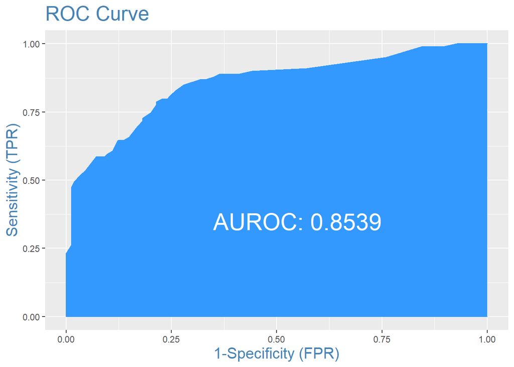

```r
plotROC(test1$Survived, predicted)
```

# Check the assumptions

##multicoleniarity test

```r
car::vif(overallmod)
```

```
##            GVIF Df GVIF^(1/(2*Df))
## Age    1.404640  1        1.185175
## SibSp  1.355082  1        1.164080
## Pclass 1.919418  2        1.177043
## Parch  1.510460  6        1.034965
## Fare   1.590652  1        1.261211
## Sex    1.169218  1        1.081304
```

The Vif test for all variables in the overall model indicates that there is no problem of collinarity where al variables have a value of VIF below 5.

#Predict the probability (p) of survival

```r
probabilities <- predict(overallmod, type = "response")
predicted.classes <- ifelse(probabilities > 0.5, "0", "1")
head(predicted.classes)
```

```
##   1   2   3   4   5   6
## "1" "0" "0" "0" "1" "1"
```

##Linearity test of independent variables and log-odds

Define continuous variables

```r
library(dplyr)
library(tidyr)
```

```r
contvar <- titanic_new01 %>%
  dplyr::select_if(is.numeric)
predictors <-colnames(contvar)

contvar <- contvar %>%
  mutate(logit = log(probabilities/(1-probabilities)))%>%
  gather(key = "predictors", value = "predictor.value", -logit)
```

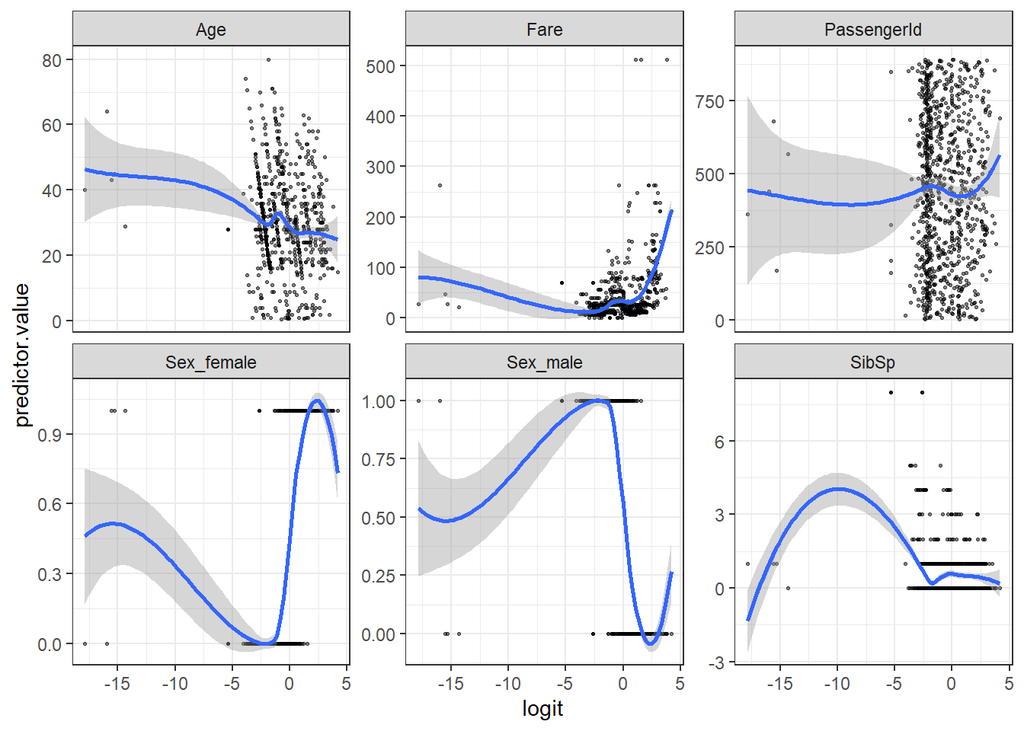

```r
ggplot(contvar, aes(logit, predictor.value))+
  geom_point(size = 0.5, alpha = 0.5) +
  geom_smooth(method = "loess") +
  theme_bw()+
  facet_wrap(~ predictors, scales = "free_y")
```

The smoothed scatter plot show that continuous variables (Age and Fare) are not linearly associated with the survival outcome in logit scale.

## influential values

Cook’s distance value

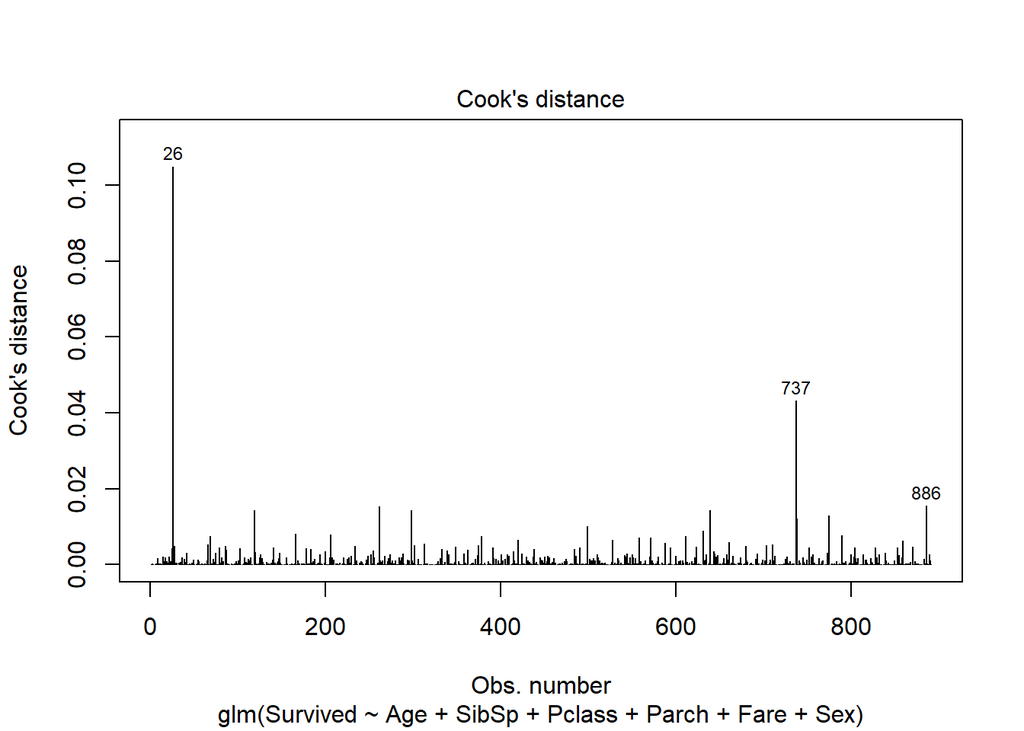

```r
plot(overallmod, which = 4, id.n = 3)
```

## cleaning the outliers

```r
titanic_clean <- titanic_new01[c(-26, -737, -886),]
overallmod_clean <- glm(Survived ~ Age+SibSp+Pclass+Parch+Fare+Sex+Embarked, data = titanic_clean, family = binomial (link = "logit"))
summary(overallmod_clean)
```

```
##
## Call:
## glm(formula = Survived ~ Age + SibSp + Pclass + Parch + Fare +
##     Sex + Embarked, family = binomial(link = "logit"), data = titanic_clean)
##
## Deviance Residuals:
##     Min       1Q   Median       3Q      Max
## -2.5778  -0.5769  -0.4162   0.6072   2.4582
##
## Coefficients:
##               Estimate Std. Error z value Pr(>|z|)
## (Intercept)  1.719e+01  1.012e+03   0.017 0.986444
## Age         -3.498e-02  8.209e-03  -4.261 2.04e-05 ***
## SibSp       -3.894e-01  1.172e-01  -3.322 0.000893 ***
## Pclass2     -9.532e-01  3.007e-01  -3.170 0.001526 **
## Pclass3     -2.094e+00  3.011e-01  -6.956 3.49e-12 ***
## Parch1       5.014e-01  2.851e-01   1.759 0.078613 .
## Parch2      -3.357e-02  3.687e-01  -0.091 0.927454
## Parch3       1.463e+00  1.423e+00   1.029 0.303649
## Parch4      -1.473e+01  6.251e+02  -0.024 0.981193
## Parch5      -1.471e+01  7.119e+02  -0.021 0.983520
## Parch6      -1.513e+01  1.455e+03  -0.010 0.991708
## Fare         2.206e-03  2.552e-03   0.864 0.387407
## Sexmale     -2.694e+00  2.009e-01 -13.410  < 2e-16 ***
## EmbarkedC   -1.337e+01  1.012e+03  -0.013 0.989454
## EmbarkedQ   -1.331e+01  1.012e+03  -0.013 0.989506
## EmbarkedS   -1.375e+01  1.012e+03  -0.014 0.989160
## ---
## Signif. codes:  0 '***' 0.001 '**' 0.01 '*' 0.05 '.' 0.1 ' ' 1
##
## (Dispersion parameter for binomial family taken to be 1)
##
##     Null deviance: 1182.80  on 887  degrees of freedom
## Residual deviance:  769.14  on 872  degrees of freedom
## AIC: 801.14
##
## Number of Fisher Scoring iterations: 14
```

```r
library(pscl)
pR2(overallmod_clean)
```

```
## fitting null model for pseudo-r2
```

```
##          llh      llhNull           G2     McFadden         r2ML         r2CU
## -384.5676897 -591.4014881  413.6675968    0.3497350    0.3723935    0.5059369
```

# 1: survival of the titanic passanger is contributed by sumber of parents and children

```r
model1 <- glm(Survived ~ Parch, data = titanic_clean, family = binomial)
summary(model1)
```

```
##
## Call:
## glm(formula = Survived ~ Parch, family = binomial, data = titanic_clean)
##
## Deviance Residuals:
##     Min       1Q   Median       3Q      Max
## -1.6651  -0.9177  -0.9177   1.4616   1.4616
##
## Coefficients:
##               Estimate Std. Error z value Pr(>|z|)
## (Intercept)   -0.64704    0.08086  -8.002 1.23e-15 ***
## Parch1         0.85113    0.20197   4.214 2.51e-05 ***
## Parch2         0.64704    0.23778   2.721  0.00651 **
## Parch3         1.74565    1.15753   1.508  0.13153
## Parch4       -14.91903  727.69877  -0.021  0.98364
## Parch5       -14.91903  840.27416  -0.018  0.98583
## Parch6       -14.91903 1455.39753  -0.010  0.99182
## ---
## Signif. codes:  0 '***' 0.001 '**' 0.01 '*' 0.05 '.' 0.1 ' ' 1
##
## (Dispersion parameter for binomial family taken to be 1)
##
##     Null deviance: 1182.8  on 887  degrees of freedom
## Residual deviance: 1150.3  on 881  degrees of freedom
## AIC: 1164.3
##
## Number of Fisher Scoring iterations: 14
```

```r
model2 <- glm(Survived ~ Age+SibSp+Pclass+Parch+Fare, data = titanic_clean, family = binomial)
summary(model2)
```

```
##
## Call:
## glm(formula = Survived ~ Age + SibSp + Pclass + Parch + Fare,
##     family = binomial, data = titanic_clean)
##
## Deviance Residuals:
##     Min       1Q   Median       3Q      Max
## -2.4125  -0.8147  -0.6657   0.9993   2.2231
##
## Coefficients:
##               Estimate Std. Error z value Pr(>|z|)
## (Intercept)  1.265e+00  3.727e-01   3.394 0.000689 ***
## Age         -3.261e-02  6.930e-03  -4.706 2.53e-06 ***
## SibSp       -3.055e-01  9.588e-02  -3.187 0.001439 **
## Pclass2     -6.226e-01  2.650e-01  -2.349 0.018829 *
## Pclass3     -1.655e+00  2.678e-01  -6.178 6.49e-10 ***
## Parch1       7.889e-01  2.392e-01   3.297 0.000976 ***
## Parch2       5.847e-01  3.206e-01   1.824 0.068169 .
## Parch3       2.101e+00  1.167e+00   1.800 0.071900 .
## Parch4      -1.479e+01  6.464e+02  -0.023 0.981742
## Parch5      -1.390e+01  8.384e+02  -0.017 0.986770
## Parch6      -1.377e+01  1.455e+03  -0.009 0.992452
## Fare         6.395e-03  2.891e-03   2.212 0.026945 *
## ---
## Signif. codes:  0 '***' 0.001 '**' 0.01 '*' 0.05 '.' 0.1 ' ' 1
##
## (Dispersion parameter for binomial family taken to be 1)
##
##     Null deviance: 1182.8  on 887  degrees of freedom
## Residual deviance: 1011.7  on 876  degrees of freedom
## AIC: 1035.7
##
## Number of Fisher Scoring iterations: 14
```

```r
model3 <- glm(Survived ~ Age+SibSp+Pclass+Fare, data = titanic_clean, family = binomial)
summary(model3)
```

```
##
## Call:
## glm(formula = Survived ~ Age + SibSp + Pclass + Fare, family = binomial,
##     data = titanic_clean)
##
## Deviance Residuals:
##     Min       1Q   Median       3Q      Max
## -2.1900  -0.8323  -0.6850   1.0267   2.2792
##
## Coefficients:
##              Estimate Std. Error z value Pr(>|z|)
## (Intercept)  1.534433   0.361178   4.248 2.15e-05 ***
## Age         -0.038360   0.006695  -5.730 1.00e-08 ***
## SibSp       -0.185907   0.083966  -2.214   0.0268 *
## Pclass2     -0.575157   0.260428  -2.209   0.0272 *
## Pclass3     -1.702892   0.262163  -6.496 8.27e-11 ***
## Fare         0.006803   0.002702   2.517   0.0118 *
## ---
## Signif. codes:  0 '***' 0.001 '**' 0.01 '*' 0.05 '.' 0.1 ' ' 1
##
## (Dispersion parameter for binomial family taken to be 1)
##
##     Null deviance: 1182.8  on 887  degrees of freedom
## Residual deviance: 1031.8  on 882  degrees of freedom
## AIC: 1043.8
##
## Number of Fisher Scoring iterations: 4
```

The model3 regression shows that all independent variables significantly predict the survival of the passenger.

To further assure the conclusion, I perform the anova test

```r
anova(model1, model2, test = "LR")
```

```
## Analysis of Deviance Table
##
## Model 1: Survived ~ Parch
## Model 2: Survived ~ Age + SibSp + Pclass + Parch + Fare
##   Resid. Df Resid. Dev Df Deviance  Pr(>Chi)
## 1       881     1150.3
## 2       876     1011.8  5   138.51 < 2.2e-16 ***
## ---
## Signif. codes:  0 '***' 0.001 '**' 0.01 '*' 0.05 '.' 0.1 ' ' 1
```

```r
anova(model2, model3, test = "LR")
```

```
## Analysis of Deviance Table
##
## Model 1: Survived ~ Age + SibSp + Pclass + Parch + Fare
## Model 2: Survived ~ Age + SibSp + Pclass + Fare
##   Resid. Df Resid. Dev Df Deviance Pr(>Chi)
## 1       876     1011.8
## 2       882     1031.8 -6  -20.038 0.002727 **
## ---
## Signif. codes:  0 '***' 0.001 '**' 0.01 '*' 0.05 '.' 0.1 ' ' 1
```

```r
anova(model1, model3, test = "LR")
```

```
## Analysis of Deviance Table
##
## Model 1: Survived ~ Parch
## Model 2: Survived ~ Age + SibSp + Pclass + Fare
##   Resid. Df Resid. Dev Df Deviance Pr(>Chi)
## 1       881     1150.3
## 2       882     1031.8 -1   118.47
```

# Calculate odds ratio and confidence interval

```r
exp(model2$coefficients[-1])
```

```
##          Age        SibSp      Pclass2      Pclass3       Parch1       Parch2
## 9.679144e-01 7.367212e-01 5.365651e-01 1.911699e-01 2.200930e+00 1.794503e+00
##       Parch3       Parch4       Parch5       Parch6         Fare
## 8.172929e+00 3.760952e-07 9.166851e-07 1.048153e-06 1.006416e+00
```

# Report the results

```r
(exp(model2$coefficients[-1])-1)*100
```

```
##         Age       SibSp     Pclass2     Pclass3      Parch1      Parch2
##  -3.2085607 -26.3278797 -46.3434858 -80.8830068 120.0930326  79.4502663
##      Parch3      Parch4      Parch5      Parch6        Fare
## 717.2928631 -99.9999624 -99.9999083 -99.9998952   0.6415992
```

Conclusions: - The passengers of class 2 odds of being survival are lower by a factor of 46% than odds ration of passenger from class 1 of being survival, as well as passenger from class 3 odds ratio of being survival is lower by 80% than odds ration class 1. - For a one unit increase in age, the odds of being survival is lower by a factor of 3.2%. - For one unit increase in number of sibling or spouse in the ship, the odds of being survival is lower by a factor of 26.32% - For one unit increase in fare, the odds of being survival is increase by a factor of 0.64%.